# IODS course project

As a bonus I perform k-means on the original Boston data with some reasonable number of clusters (> 2). The data is already standardized. I then perform LDA using the clusters as target classes and visualize the results.

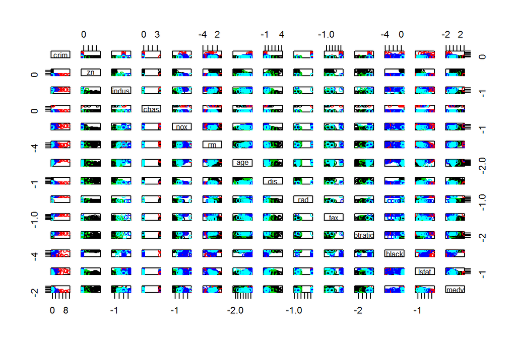

```r
#k-means clustering
set.seed(123)
km <-kmeans(dist_eu, centers=5)
pairs(Boston, col = km$cluster)
```

```r
summary(km$cluster)
```

```
##    Min. 1st Qu.  Median    Mean 3rd Qu.    Max.
##   1.000   3.000   3.000   3.271   4.000   5.000
```

```r
#linear discriminant analysis
lda.fit2 <- lda(km$cluster ~ ., data = Boston)

#print the lda.fit object
lda.fit2
```

```
## Call:
## lda(km$cluster ~ ., data = Boston)
##
## Prior probabilities of groups:
##          1          2          3          4          5
## 0.18181818 0.04940711 0.30830040 0.23715415 0.22332016
##
## Group means:
##         crim          zn      indus        chas         nox          rm
## 1 -0.3951599  1.49373012 -1.0280299  0.24120575 -0.79647759  1.13584087
## 2  2.3352128 -0.48724019  1.0667704  1.30251103  1.26154533 -0.21940026
## 3 -0.4023867 -0.08196879 -0.6708441 -0.27232907 -0.71691589  0.02477035
## 4  0.6361371 -0.48724019  1.0979228 -0.14109239  1.22360302 -0.52042480
## 5 -0.3149534 -0.47775410  0.3611543  0.04124529  0.05967983 -0.35774825
##          age        dis        rad        tax    ptratio      black
## 1 -0.8400953  0.9065514 -0.6086194 -0.6502772 -0.9991671  0.3389339
## 2  0.9111949 -1.0255574  1.1359019  1.1548960  0.1960633 -1.4567920
## 3 -0.6577632  0.5759944 -0.5681286 -0.7193879 -0.1594854  0.3766108
## 4  0.8391434 -0.8692421  1.3447315  1.3861705  0.5748257 -0.6192283
## 5  0.4993164 -0.3832732 -0.3995070 -0.2049809  0.3798444  0.1840176
##        lstat       medv
## 1 -0.9505678  1.2087711
## 2  0.9594283 -0.3815121
## 3 -0.5318895  0.1487245
## 4  0.9216212 -0.7473700
## 5  0.3172279 -0.3113784
##
## Coefficients of linear discriminants:
##                 LD1        LD2         LD3        LD4
## crim     0.19491189 -0.7127609 -1.14924280 -0.4608763
## zn       0.35812428 -1.0396097  0.41431106  0.9408250
## indus    0.37857256  0.4320719 -0.20011161  0.3773144
## chas     0.29883290 -0.4237586 -0.56277369  0.0735374
## nox      1.33917666 -0.7169740  0.23530741 -0.3177065
## rm      -0.17927152 -0.4166834  0.10365939  0.2117328
## age      0.15598107  0.1800961 -0.11147413  0.7095433
## dis     -0.03700046 -0.2845778 -0.08357663 -0.5600861
## rad      0.16954940  0.4993418  1.27959574 -1.1399167
## tax      1.23874792 -0.7752553  0.04457017  0.4981892
## ptratio  0.34173317  0.1200696 -0.24570231  0.4987949
## black   -0.25233271  0.2567087  0.35218105  0.1031269
## lstat    0.55251648 -0.4613707 -0.02975811  0.4062116
## medv     0.29066860 -0.9089058 -0.26660104  0.2170107
##
## Proportion of trace:
##    LD1    LD2    LD3    LD4
## 0.7810 0.1546 0.0369 0.0275
```

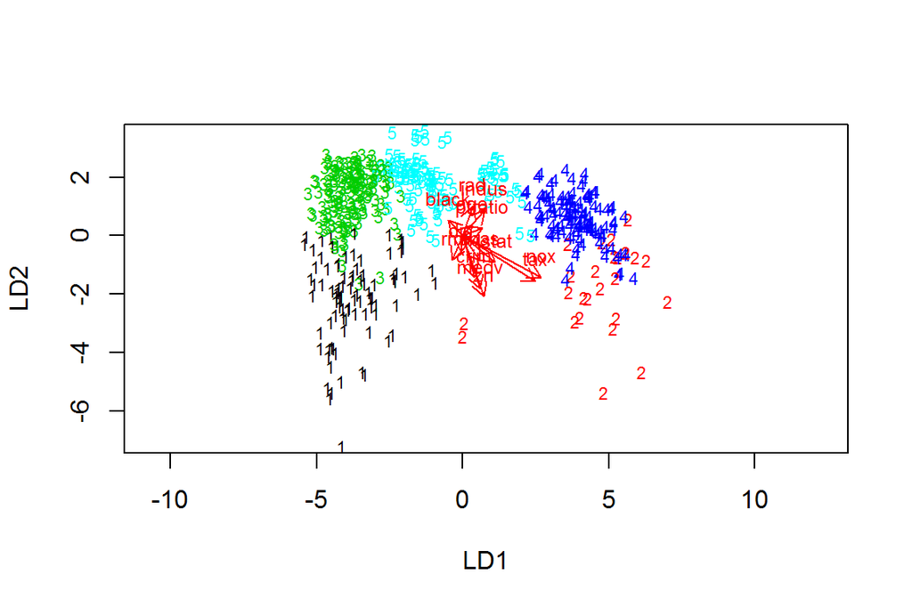

```r
#the function for lda biplot arrows
lda.arrows2 <- function(x, myscale = 1, arrow_heads = 0.1, color = "red", tex = 0.75, choices = c(1,2)){
  heads <- coef(x)
  arrows(x0 = 0, y0 = 0,
         x1 = myscale * heads[,choices[1]],
         y1 = myscale * heads[,choices[2]], col=color, length = arrow_heads)
  text(myscale * heads[,choices], labels = row.names(heads),
       cex = tex, col=color, pos=3)
}

# target classes as numeric
classes2 <- as.numeric(km$cluster)

# plot the lda results
plot(lda.fit2, dimen = 2, col=classes2, pch=classes)
lda.arrows2(lda.fit2, myscale = 2)
```

# RStudio Exercise 5

## Describing the dataset

The ‘human’ dataset originates from the United Nations Development Program. More information about the dataset can be found here: http://hdr.undp.org/en/content/human-development-index-hdi. In this assignment, I use the dataset which has 8 variables and 155 countries. The variables of the dataset describe health, economic and gender equality of each country. Below is the list of the variable names and descriptions.

> - “GNI” = Gross National Income per capita
> - “Life.Exp” = Life expectancy at birth
> - “Edu.Exp” = Expected years of schooling
> - “Mat.Mor” = Maternal mortality ratio
> - “Ado.Birth” = Adolescent birth rate
> - “Parli.F” = Percetange of female representatives in parliament
> - “Edu2.FM” = the ratio of Female and Male populations with secondary education in each country
> - “Labo.FM” = the ratio of labour force participation of females and males in each country

Below is the summary of the data. We see that the variables have very different scales. The differences between the scales are important for later analyses.

```r
summary(human)
```

```
##     Edu2.FM          Labo.FM          Edu.Exp         Life.Exp
##  Min.   :0.1717   Min.   :0.1857   Min.   : 5.40   Min.   :49.00
##  1st Qu.:0.7264   1st Qu.:0.5984   1st Qu.:11.25   1st Qu.:66.30
##  Median :0.9375   Median :0.7535   Median :13.50   Median :74.20
##  Mean   :0.8529   Mean   :0.7074   Mean   :13.18   Mean   :71.65
##  3rd Qu.:0.9968   3rd Qu.:0.8535   3rd Qu.:15.20   3rd Qu.:77.25
##  Max.   :1.4967   Max.   :1.0380   Max.   :20.20   Max.   :83.50
##       GNI            Mat.Mor         Ado.Birth         Parli.F
##  Min.   :   581   Min.   :   1.0   Min.   :  0.60   Min.   : 0.00
##  1st Qu.:  4198   1st Qu.:  11.5   1st Qu.: 12.65   1st Qu.:12.40
##  Median : 12040   Median :  49.0   Median : 33.60   Median :19.30
##  Mean   : 17628   Mean   : 149.1   Mean   : 47.16   Mean   :20.91
##  3rd Qu.: 24512   3rd Qu.: 190.0   3rd Qu.: 71.95   3rd Qu.:27.95
##  Max.   :123124   Max.   :1100.0   Max.   :204.80   Max.   :57.50
```

Just for curiosity, here is how Finland is doing

```r
human[22,]
```

```
##         Edu2.FM   Labo.FM Edu.Exp Life.Exp   GNI Mat.Mor Ado.Birth Parli.F
## Finland       1 0.8703125    17.1     80.8 38695       4       9.2    42.5
```

And some other countries as well. As expected, there are huge differences between countries.

```r
head(human, n=5)
```

```
##               Edu2.FM   Labo.FM Edu.Exp Life.Exp   GNI Mat.Mor Ado.Birth
## Norway      1.0072389 0.8908297    17.5     81.6 64992       4       7.8
## Australia   0.9968288 0.8189415    20.2     82.4 42261       6      12.1
## Switzerland 0.9834369 0.8251001    15.8     83.0 56431       6       1.9
## Denmark     0.9886128 0.8840361    18.7     80.2 44025       5       5.1
## Netherlands 0.9690608 0.8286119    17.9     81.6 45435       6       6.2
##             Parli.F
## Norway         39.6
## Australia      30.5
## Switzerland    28.5
## Denmark        38.0
## Netherlands    36.9
```

```r
tail(human, n=5)
```

```
##                            Edu2.FM   Labo.FM Edu.Exp Life.Exp  GNI Mat.Mor
## Burkina Faso             0.2812500 0.8566667     7.8     58.7 1591     400
## Burundi                  0.6385542 1.0158537    10.1     56.7  758     740
## Chad                     0.1717172 0.8080808     7.4     51.6 2085     980
## Central African Republic 0.3782772 0.8531140     7.2     50.7  581     880
## Niger                    0.3076923 0.4459309     5.4     61.4  908     630
##                          Ado.Birth Parli.F
## Burkina Faso                 115.4    13.3
## Burundi                       30.3    34.9
## Chad                         152.0    14.9
## Central African Republic      98.3    12.5
## Niger                        204.8    13.3
```

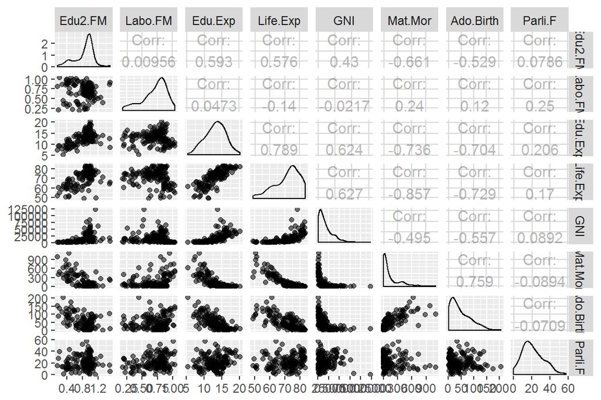

```r
p <- ggpairs(human, mapping = aes(alpha = 0.3), lower = list(combo = wrap("facethist", bins = 20)))
p
```

## Principal Component Analysis

### Non-standardized data

Next I perform principal component analysis (PCA) on the not standardized human data. My goal is to find the components that capture the most of the variance. PCA can be performed by two slightly different matrix decomposition methods from linear algebra: the Eigenvalue Decomposition and the Singular Value Decomposition (SVD). In this assignment, I used the SVD method. I use the prcomp() function which decompose a data matrix into a product of smaller matrices, which let’s us extract the underlying principal components. This makes it possible to approximate a lower dimensional representation of the data by choosing only a few principal components.

```r
pca_human <- prcomp(human)
pca_human
```

```
## Standard deviations:
## [1] 1.854416e+04 1.855219e+02 2.518701e+01 1.145441e+01 3.766241e+00
## [6] 1.565912e+00 1.912052e-01 1.591112e-01
##
## Rotation:
##                     PC1           PC2           PC3           PC4
## Edu2.FM   -5.607472e-06  0.0006713951 -3.412027e-05 -2.736326e-04
## Labo.FM    2.331945e-07 -0.0002819357  5.302884e-04 -4.692578e-03
## Edu.Exp   -9.562910e-05  0.0075529759  1.427664e-02 -3.313505e-02
## Life.Exp  -2.815823e-04  0.0283150248  1.294971e-02 -6.752684e-02
## GNI       -9.999832e-01 -0.0057723054 -5.156742e-04  4.932889e-05
## Mat.Mor    5.655734e-03 -0.9916320120  1.260302e-01 -6.100534e-03
## Ado.Birth  1.233961e-03 -0.1255502723 -9.918113e-01  5.301595e-03
## Parli.F   -5.526460e-05  0.0032317269 -7.398331e-03 -9.971232e-01
##                     PC5           PC6           PC7           PC8
## Edu2.FM   -0.0022935252  2.180183e-02  6.998623e-01  7.139410e-01
## Labo.FM    0.0022190154  3.264423e-02  7.132267e-01 -7.001533e-01
## Edu.Exp    0.1431180282  9.882477e-01 -3.826887e-02  7.776451e-03
## Life.Exp   0.9865644425 -1.453515e-01  5.380452e-03  2.281723e-03
## GNI       -0.0001135863 -2.711698e-05 -8.075191e-07 -1.176762e-06
## Mat.Mor    0.0266373214  1.695203e-03  1.355518e-04  8.371934e-04
## Ado.Birth  0.0188618600  1.273198e-02 -8.641234e-05 -1.707885e-04
## Parli.F   -0.0716401914 -2.309896e-02 -2.642548e-03  2.680113e-03
```

In PCA, the data is first transformed to a new space with equal or less number of dimensions. These new features are called the principal components. The 1st principal component (PC1) captures the maximum amount of variance from the features in the original data. The 2nd principal component (PC2) is orthogonal to the first and it captures the maximum amount of variability left. The same is true for each principal component. They are all uncorrelated and each is less important than the previous one, in terms of captured variance. With our data, we found 8 principal components. Lets see the importance of different components.

```r
summary(pca_human)
```

```
## Importance of components:
##                              PC1      PC2   PC3   PC4   PC5   PC6    PC7
## Standard deviation     1.854e+04 185.5219 25.19 11.45 3.766 1.566 0.1912
## Proportion of Variance 9.999e-01   0.0001  0.00  0.00 0.000 0.000 0.0000
## Cumulative Proportion  9.999e-01   1.0000  1.00  1.00 1.000 1.000 1.0000
##                           PC8
## Standard deviation     0.1591
## Proportion of Variance 0.0000
## Cumulative Proportion  1.0000
```

```r
# create and print out a summary of pca_human
s <- summary(pca_human)
# rounded percetanges of variance captured by each PC
pca_pr <- round(100*s$importance[2, ], digits = 1)
# create object pc_lab to be used as axis labels
pc_lab <- paste0(names(pca_pr), " (", pca_pr, "%)")
```

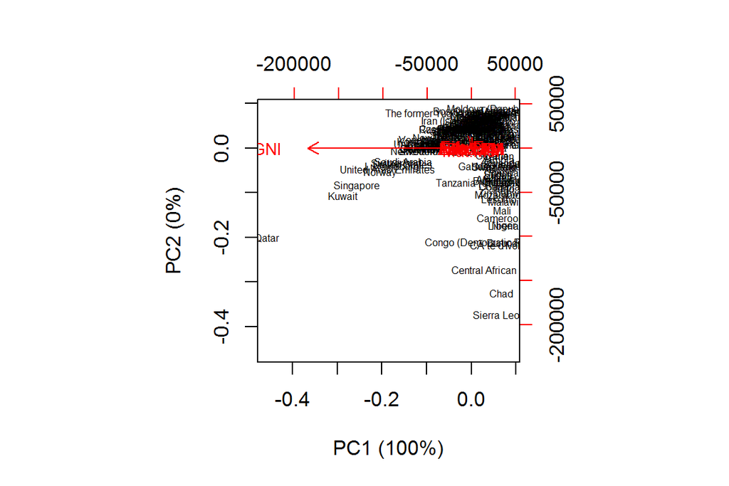

```r
# draw a biplot
biplot(pca_human, cex = c(0.5, 0.8), xlab = pc_lab[1], ylab = pc_lab[2])
```

This biplot suggests that almost all of the variance is caused by one GNI, Gross National Income per capita. PCA is sensitive to the relative scaling of the original features and assumes that features with larger variance are more important than features with smaller variance. GNI has the largest scale (min: 581, max: 123,100). Therefore I’ll do the analysis again, but with this time by standardized data.

### Standardized data

```r
#scale the dataset
human_st <- scale(human)
#Pca on standardized data
pca_human_st <- prcomp(human_st)
pca_human_st
```

```
## Standard deviations:
## [1] 2.0708380 1.1397204 0.8750485 0.7788630 0.6619563 0.5363061 0.4589994
## [8] 0.3222406
##
## Rotation:
##                   PC1         PC2         PC3         PC4        PC5
## Edu2.FM   -0.35664370  0.03796058 -0.24223089  0.62678110 -0.5983585
## Labo.FM    0.05457785  0.72432726 -0.58428770  0.06199424  0.2625067
## Edu.Exp   -0.42766720  0.13940571 -0.07340270 -0.07020294  0.1659678
## Life.Exp  -0.44372240 -0.02530473  0.10991305 -0.05834819  0.1628935
## GNI       -0.35048295  0.05060876 -0.20168779 -0.72727675 -0.4950306
## Mat.Mor    0.43697098  0.14508727 -0.12522539 -0.25170614 -0.1800657
## Ado.Birth  0.41126010  0.07708468  0.01968243  0.04986763 -0.4672068
## Parli.F   -0.08438558  0.65136866  0.72506309  0.01396293 -0.1523699
##                   PC6         PC7         PC8
## Edu2.FM    0.17713316  0.05773644  0.16459453
## Labo.FM   -0.03500707 -0.22729927 -0.07304568
## Edu.Exp   -0.38606919  0.77962966 -0.05415984
## Life.Exp  -0.42242796 -0.43406432  0.62737008
## GNI        0.11120305 -0.13711838 -0.16961173
## Mat.Mor    0.17370039  0.35380306  0.72193946
## Ado.Birth -0.76056557 -0.06897064 -0.14335186
## Parli.F    0.13749772  0.00568387 -0.02306476
```

```r
summary(pca_human_st)
```

```
## Importance of components:
##                           PC1    PC2     PC3     PC4     PC5     PC6
## Standard deviation     2.0708 1.1397 0.87505 0.77886 0.66196 0.53631
## Proportion of Variance 0.5361 0.1624 0.09571 0.07583 0.05477 0.03595
## Cumulative Proportion  0.5361 0.6984 0.79413 0.86996 0.92473 0.96069
##                            PC7     PC8
## Standard deviation     0.45900 0.32224
## Proportion of Variance 0.02634 0.01298
## Cumulative Proportion  0.98702 1.00000
```

The results of the PCA with standardized data are clearly different. Now the first two components explain 53.6% and 16.2% of the variance in our dataset. The variables having strongest loadings on PC1 are maternal mortality ratio and adolescent birth rate. The strongest negative loadings on PC1 are life expectancy, expected years of schooling, the ratio of females to males with secondary education, and gross national income per capita. The variables having strongest loadings on PC2 are the ratio of females to males in labor and female parliamentary representation. The first principal component seems to describe health and economic factors of the countries, and the second describes the gender equality in participating in politics and labor. Together these two component explained 70 percentages of the variance between countries.

```r
s_td <- summary(pca_human_st)
# rounded percetanges of variance captured by each PC
pca_pr2 <- round(100*s_td$importance[2, ], digits = 1)
# create object pc_lab to be used as axis labels
pc_lab2 <- paste0(names(pca_pr2), "(", pca_pr2, "%)")
```

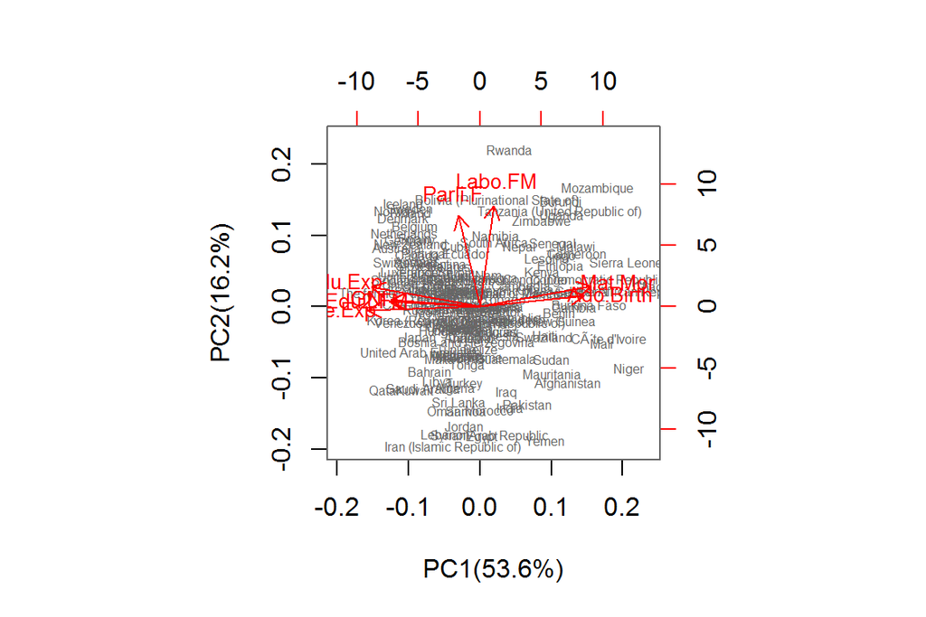

```r
# draw a biplot
biplot(pca_human_st, cex = c(0.5, 0.8), col = c("grey40", "red"), xlab = pc_lab2[1], ylab = pc_lab2[2])
```

From the biplot we see that, for instance, Iceland has high gender equality, giving birth is safe to a woman’s health, and women tend to participate in politics and labor force more than most of the countries. Many African and Asian countries such as Niger and Afghanistan, for instance, are poor countries where people have short life expectancy, women tend to have many children and giving birth is dangerous, and women do not participate in politics and labor. Rwanda seems an interesting case since they have women participating in politics and labor force but it is still a poor country relatively high maternal mortality and adolescent birth rate. Qatar, Kuwait and Saudi Arabia are among the wealthiest countries in the world but women do not participate in the labor force or politics. This biplot clearly states that if we want to measure well-being of populations of different countries, many measures are needed. Also, gender inequality is not automatically improving when gross national income per capita improves.

## Multiple Correspondence Analysis

I installed the packages FactoMineR and here is the dataset “tea”.

```r
dim(tea)
```

```
## [1] 300  36
```

```r
str(tea)
```

```
## 'data.frame':    300 obs. of  36 variables:
##  $ breakfast       : Factor w/ 2 levels "breakfast","Not.breakfast": 1 1 2 2 1 2 1 2 1 1 ...
##  $ tea.time        : Factor w/ 2 levels "Not.tea time",..: 1 1 2 1 1 1 2 2 2 1 ...
##  $ evening         : Factor w/ 2 levels "evening","Not.evening": 2 2 1 2 1 2 2 1 2 1 ...
##  $ lunch           : Factor w/ 2 levels "lunch","Not.lunch": 2 2 2 2 2 2 2 2 2 2 ...
##  $ dinner          : Factor w/ 2 levels "dinner","Not.dinner": 2 2 1 1 2 1 2 2 2 2 ...
##  $ always          : Factor w/ 2 levels "always","Not.always": 2 2 2 2 1 2 2 2 2 2 ...
##  $ home            : Factor w/ 2 levels "home","Not.home": 1 1 1 1 1 1 1 1 1 1 ...
##  $ work            : Factor w/ 2 levels "Not.work","work": 1 1 2 1 1 1 1 1 1 1 ...
##  $ tearoom         : Factor w/ 2 levels "Not.tearoom",..: 1 1 1 1 1 1 1 1 1 2 ...
##  $ friends         : Factor w/ 2 levels "friends","Not.friends": 2 2 1 2 2 2 1 2 2 2 ...
##  $ resto           : Factor w/ 2 levels "Not.resto","resto": 1 1 2 1 1 1 1 1 1 1 ...
##  $ pub             : Factor w/ 2 levels "Not.pub","pub": 1 1 1 1 1 1 1 1 1 1 ...
##  $ Tea             : Factor w/ 3 levels "black","Earl Grey",..: 1 1 2 2 2 2 2 1 2 1 ...
##  $ How             : Factor w/ 4 levels "alone","lemon",..: 1 3 1 1 1 1 1 3 3 1 ...
```

[output cut: 22 more lines]

I select six variables for a new dataset and draw a graph. My new dataset consists of six variables describing how one does drink tea, what kind of tea, does one drink tea during lunch, does one drink tea with sugar, where one buys his or her tea, and the gender of the person.

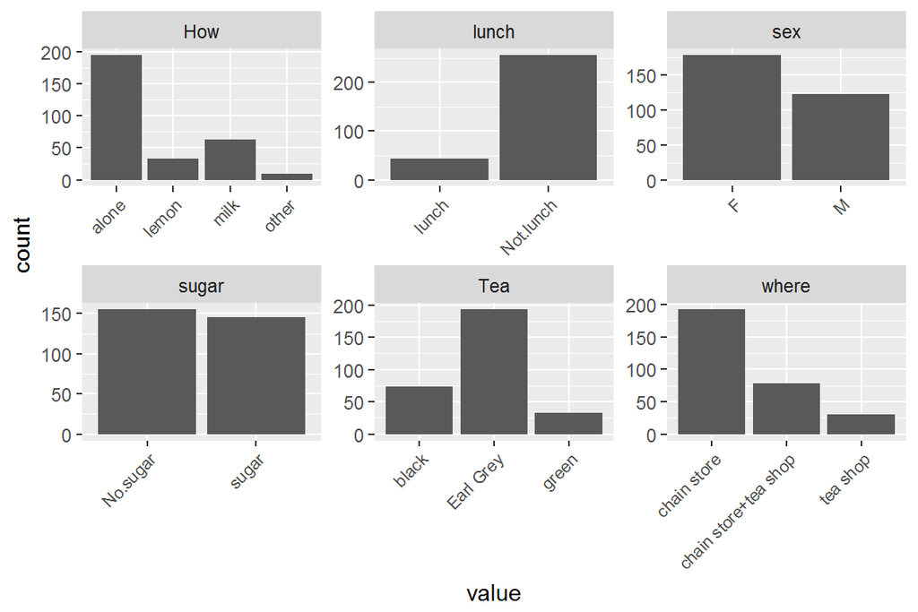

```r
# column names to keep in the dataset
keep_columns <- c("Tea", "How", "sugar", "where", "lunch", "sex")
# select the 'keep_columns' to create a new dataset
tea_time <- dplyr::select(tea, one_of(keep_columns))
# visualize the dataset
gather(tea_time) %>% ggplot(aes(value)) + geom_bar() + theme(axis.text.x = element_text(angle = 45, hjust = 1, size = 8)) + facet_wrap("key", scales = "free")
```

Next I’ll do multiple correspondence analysis (MCA) which is a method to analyze qualitative data and can be used to detect patterns or structure in the data as well as in dimension reduction.

```r
# multiple correspondence analysis
mca <- MCA(tea_time, graph = FALSE)
# summary of the model
summary(mca)
```

```
##
## Call:
## MCA(X = tea_time, graph = FALSE)
##
##
## Eigenvalues
##                        Dim.1   Dim.2   Dim.3   Dim.4   Dim.5   Dim.6
## Variance               0.227   0.223   0.212   0.194   0.179   0.148
## % of var.             13.646  13.366  12.707  11.641  10.722   8.853
## Cumulative % of var.  13.646  27.012  39.720  51.361  62.083  70.936
##                        Dim.7   Dim.8   Dim.9  Dim.10
## Variance               0.141   0.127   0.120   0.096
## % of var.              8.434   7.621   7.223   5.786
## Cumulative % of var.  79.370  86.991  94.214 100.000
##
## Individuals (the 10 first)
##                Dim.1    ctr   cos2    Dim.2    ctr   cos2    Dim.3    ctr
## 1           | -0.262  0.101  0.060 | -0.202  0.061  0.036 |  0.345  0.187
## 2           |  0.413  0.250  0.112 | -0.441  0.292  0.127 |  0.126  0.025
## 3           |  0.099  0.014  0.017 | -0.285  0.121  0.141 | -0.581  0.531
## 4           | -0.492  0.354  0.333 |  0.218  0.071  0.066 | -0.083  0.011
## 5           | -0.223  0.073  0.071 | -0.227  0.077  0.073 | -0.159  0.040
## 6           | -0.223  0.073  0.071 | -0.227  0.077  0.073 | -0.159  0.040
## 7           | -0.223  0.073  0.071 | -0.227  0.077  0.073 | -0.159  0.040
## 8           |  0.413  0.250  0.112 | -0.441  0.292  0.127 |  0.126  0.025
## 9           |  0.309  0.140  0.059 |  0.278  0.116  0.048 |  0.365  0.210
## 10          |  0.454  0.301  0.137 | -0.405  0.245  0.109 |  0.514  0.416
##               cos2
## 1            0.104 |
## 2            0.010 |
## 3            0.587 |
## 4            0.009 |
## 5            0.036 |
## 6            0.036 |
## 7            0.036 |
## 8            0.010 |
## 9            0.082 |
## 10           0.176 |
##
## Categories (the 10 first)
```

[output cut: 16 more lines]

```
## lemon         7.589 |   1.023   9.065   0.129   6.221 |
## milk          3.792 |   0.386   2.464   0.040   3.442 |
## other        -1.868 |   1.846   8.045   0.105   5.614 |
## No.sugar    -10.898 |  -0.101   0.419   0.011  -1.814 |
## sugar        10.898 |   0.108   0.448   0.011   1.814 |
## chain store  -3.232 |  -0.353   6.284   0.222  -8.144 |
##
## Categorical variables (eta2)
##               Dim.1 Dim.2 Dim.3
## Tea         | 0.275 0.413 0.255 |
## How         | 0.292 0.287 0.344 |
## sugar       | 0.147 0.397 0.011 |
## where       | 0.442 0.117 0.309 |
## lunch       | 0.002 0.115 0.024 |
## sex         | 0.205 0.006 0.327 |
```

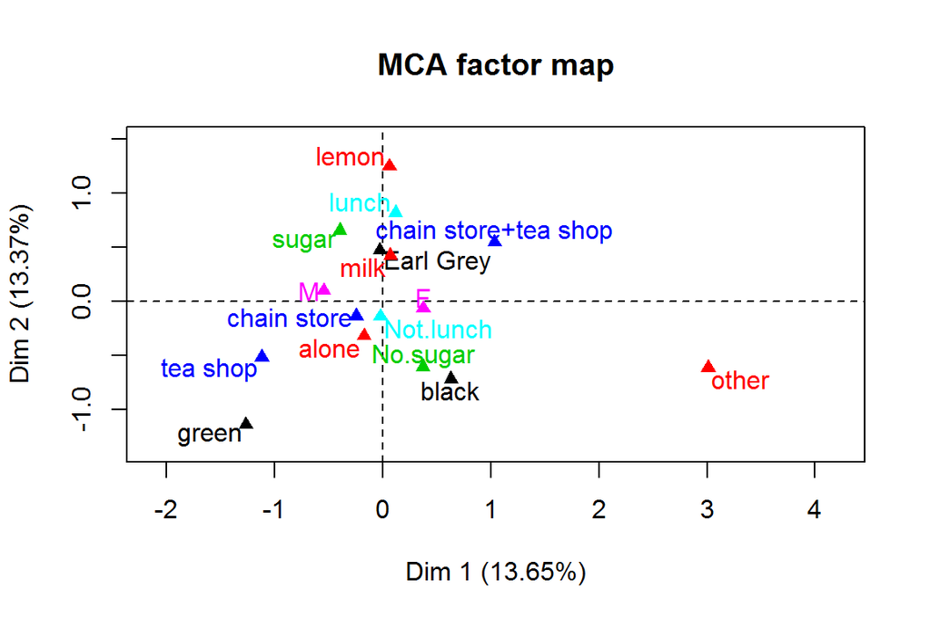

```r
#draw a plot
plot(mca, invisible=c("ind"), habillage = "quali")
```

```r
s <- summary(mca)
# rounded percetanges of variance captured by each PC
s2 <- round(100*s$importance[2, ], digits = 1)
# create object pc_lab to be used as axis labels
s2_lab <- paste0(names(s2), "(", s2, "%)")
```